# HW0_Solution

```r
library("glmnet")
library("ISLR")
```

```r
set.seed(1)
# Make a model matrix as in the R lab video.
X.model = model.matrix(Salary ~ .- League -Division -NewLeague, data = Hitters)
head(X.model)
```

```
##                   (Intercept) AtBat Hits HmRun Runs RBI Walks Years CAtBat
## -Alan Ashby                 1   315   81     7   24  38    39    14   3449
## -Alvin Davis                1   479  130    18   66  72    76     3   1624
## -Andre Dawson               1   496  141    20   65  78    37    11   5628
## -Andres Galarraga           1   321   87    10   39  42    30     2    396
## -Alfredo Griffin            1   594  169     4   74  51    35    11   4408
## -Al Newman                  1   185   37     1   23   8    21     2    214
##                   CHits CHmRun CRuns CRBI CWalks PutOuts Assists Errors
## -Alan Ashby         835     69   321  414    375     632      43     10
## -Alvin Davis        457     63   224  266    263     880      82     14
## -Andre Dawson      1575    225   828  838    354     200      11      3
## -Andres Galarraga   101     12    48   46     33     805      40      4
## -Alfredo Griffin   1133     19   501  336    194     282     421     25
## -Al Newman           42      1    30    9     24      76     127      7
```

```r
y = Hitters$Salary

# remove the NAs:
y <-na.omit(y)
```

## LASSO Regression

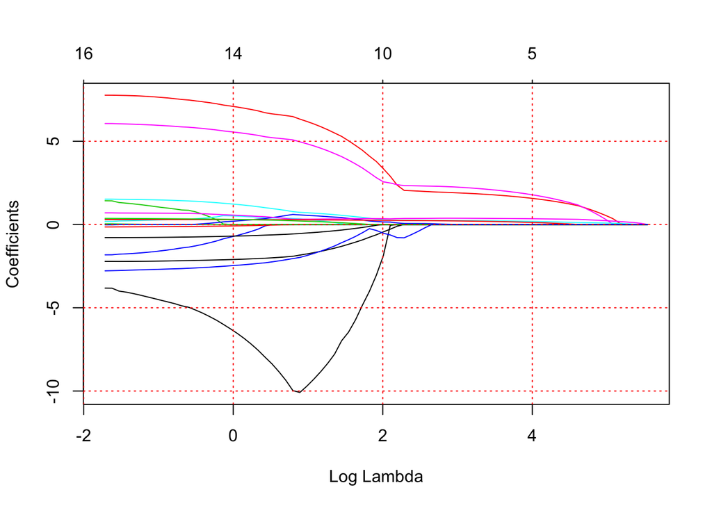

```r
# Make a sequence of ridge regression models and plot:
fit.lasso = glmnet(X.model, y, alpha = 1)
plot(fit.lasso, xvar = "lambda")
grid(col = 2)
```

The trajectory plot tells us when each feature leaves the model as we increase the amount of penalization. The matrix “beta” tells us the estimated coefficients for each feature, at each different value of Lambda. Using this, we can isolate the last few variables that are left in the model.

```r
fit.lasso$beta[,6]
```

```
## (Intercept)       AtBat        Hits       HmRun        Runs         RBI
##  0.00000000  0.00000000  0.35506637  0.00000000  0.00000000  0.00000000
##       Walks       Years      CAtBat       CHits      CHmRun       CRuns
##  0.02872523  0.00000000  0.00000000  0.00000000  0.00000000  0.07946852
##        CRBI      CWalks     PutOuts     Assists      Errors
##  0.20576671  0.00000000  0.00000000  0.00000000  0.00000000
```

But such a model wouldn’t necessarily be the best model - we have decide which value of Lambda is the best choice. We can use cross validation to evaluate a large range of possible Lambda values. Then we can pick the value of the Lambda that results in the smallest cross validation error.

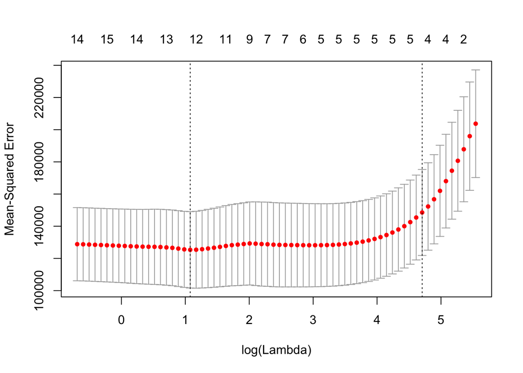

```r
cv.lasso = cv.glmnet(X.model,y,alpha = 1)
plot(cv.lasso)
```

```r
print(log(cv.lasso$lambda.min))
```

```
## [1] 1.07675
```

```r
print(log(cv.lasso$lambda.1se))
```

```
## [1] 4.705066
```

Above is a Cross Validation plot for Lambda. Note that the true minimum is around log(Lambda)=1.1 but that variability due to sampling yields a 1-standard-error Lambda of around 4.7. This means that the most amount of regularization that we should accept corresponds to log(Lambda)=4.7. But any model with log(Lambda) less that 4.7 would yield comparable results in terms of cross validation error, so these would all be fine choices. (Worse, there is a fair amount of variability to the answer here simply to due to sampling variances, and different random seeds will yields different results. Let’s attribute this to the relatively tiny size of this data set.)

Now let’s pick our optimal model, and extract the features and coefficients for that model. These are the features that remain in the model at this particular value of Lambda.

```r
lasso.best = glmnet(X.model, y, alpha=1, lambda=exp(1.1))
print(lasso.best$beta)
```

```
## 17 x 1 sparse Matrix of class "dgCMatrix"
##                     s0
## (Intercept)  .
## AtBat       -1.6899021
## Hits         6.0423234
## HmRun        .
## Runs         .
## RBI          0.2495404
## Walks        4.7202584
## Years       -8.9237381
## CAtBat       .
## CHits        .
## CHmRun       0.5683865
## CRuns        0.6907433
## CRBI         0.3041368
## CWalks      -0.4846735
## PutOuts      0.2799460
## Assists      0.1800185
## Errors      -1.6755037
```

## Ridge Regression

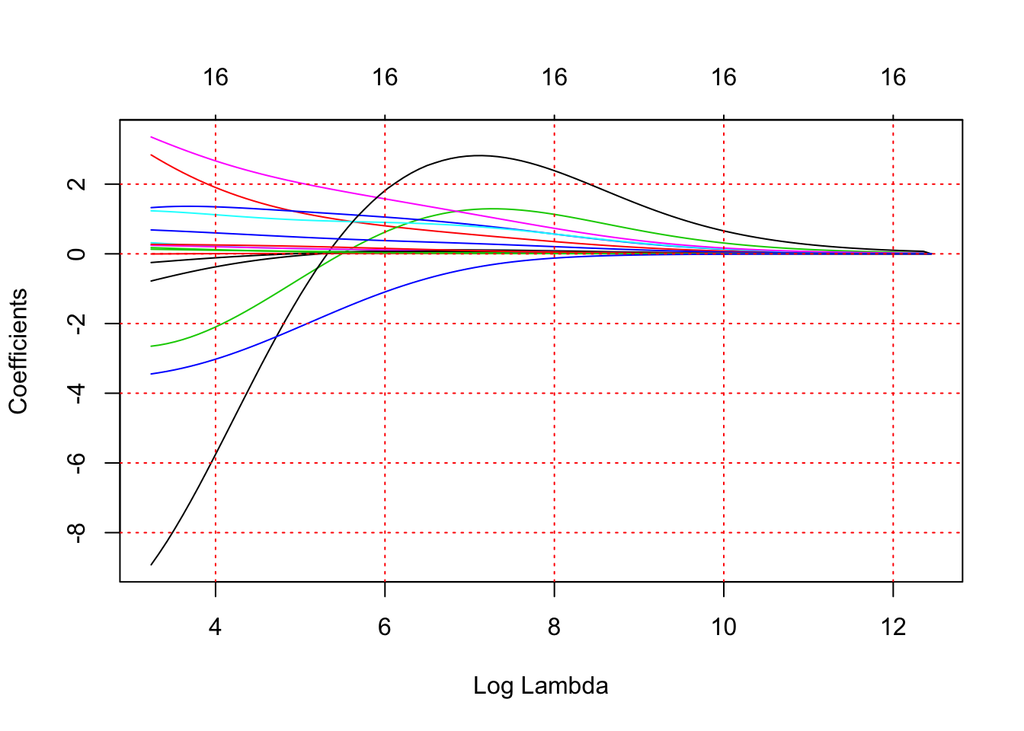

```r
fit.ridge = glmnet(X.model, y, alpha = 0)
plot(fit.ridge, xvar = "lambda")
grid(col = 2)
```

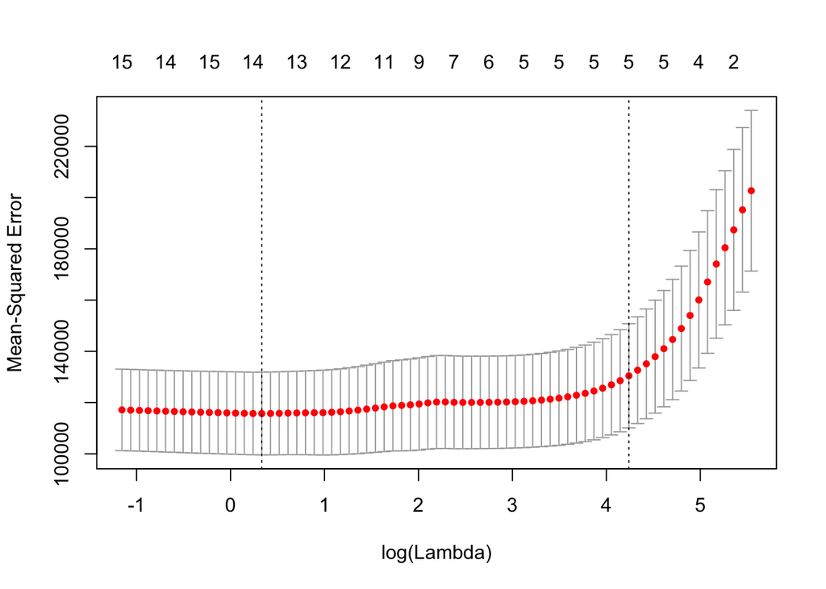

```r
cv.ridge = cv.glmnet(X.model,y,alpha = 1)
plot(cv.ridge)
```

```r
print(log(cv.ridge$lambda.min))
```

```
## [1] 0.3324797
```

```r
print(log(cv.ridge$lambda.1se))
```

```
## [1] 4.239897
```

## Short Answer

The bias-variance tradeoff describes the problem of overfitting and underfitting models. We can think of bias as a quantification of how well a model can fit a training data set. We can think of variance (in this context) as describing how much a model-fit might change upon being trained on new data points. Thus, variance is a quantification of how well a model can generalize to unseen data. Techniques which are more flexible tend to yields models with low bias yet high variance. Conversely, techniques which are less flexible tend to yield models with high bias and low variance.